# BIO782P - Week 2 Assignment

Ana Penedos (UID 1932)

14th December 2018

# Part A

- effect of nicotine concentration on the nervous system
- giant squid axons submitted to different nicotine concentrations
- electric stimulus of increasing voltages was applied to each axon
- peak response voltage recorded for 3ms after each electric stimulus
- measured action potentials (in mV)

## input data

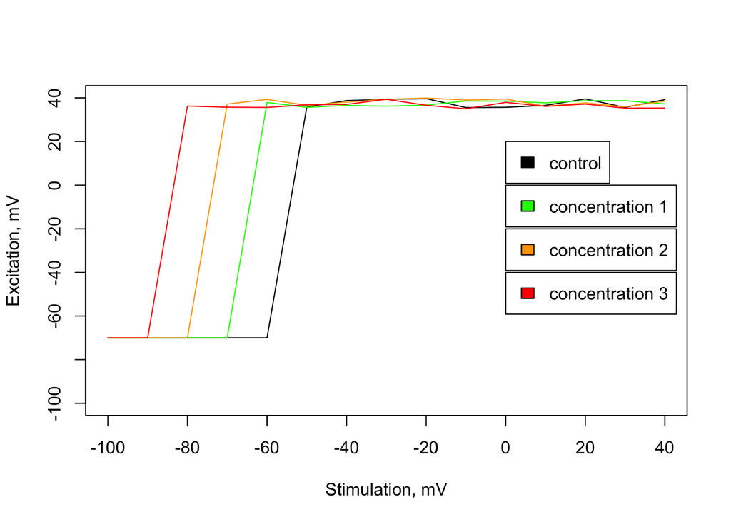

```r
stimulation_potential = seq(-100, 40, by=10)
response_voltage_control = c(-70.00000,-70.00000,-70.00000,-70.00000,-70.00000,35.79871,38.75082,39.30423,39.65390,35.55835,35.66762,36.55754,39.51027,35.65274,39.17013)
response_voltage_concN_1 = c(-70.00000,-70.00000,-70.00000,-70.00000,37.88144,35.64345,36.54319,36.18773,36.67542,38.56634,38.53102,37.73421,38.69826,38.67744,37.21896)
response_voltage_concN_2 = c(-70.00000,-70.00000,-70.00000,37.16110,39.28471,36.57506,38.03037,39.37853,39.92131,39.01116,39.46393,36.16073,37.70418,35.88598,38.53137)
response_voltage_concN_3 = c(-70.00000,-70.00000,36.25729,35.70035,35.61478,36.81245,37.01299,39.34139,36.59520,35.00749,37.94440,36.10611,37.15617,35.29182,35.32412)

plot(stimulation_potential,stimulation_potential,type='n',xlab='Stimulation, mV',ylab='Excitation, mV')
lines(stimulation_potential,response_voltage_control)
lines(stimulation_potential,response_voltage_concN_1,col="green")
lines(stimulation_potential,response_voltage_concN_2,col="orange")
lines(stimulation_potential,response_voltage_concN_3,col="red")

legend(0,20,"control",fill="black")
legend(0,00,"concentration 1",fill="green")
legend(0,-20,"concentration 2",fill="orange")
legend(0,-40,"concentration 3",fill="red")
```

## 1. Describe what the inputs, outputs and role for each of the functions predict, calculate_errors and fit_threshold are.

```r
predict = function(activation_threshold,stimulation_voltage){
  # Produces a vector of activation values (mV) based on whether the
  # stimulation voltage is less or equal (-70) or greater (40) than the activation threshold.
  #
  # Args:
  #   activation_threshold: the voltage at which the axon becomes
  #                         activated (numeric).
  #   stimulation_voltage: the voltages at which the axon was stimulated
  #                        (vector of numeric values).
  #
  # Returns: vector of same length as the stimulation_voltage argument
  #
  #

  # produces a vector of '-70's the same length as the variable
  # 'stimulation_voltage'
  activation = rep(-70,length(stimulation_voltage))
  # Values in position x of activation are changed based on
  # the value in position x of stimulation_voltage.
  # When stimulation_voltage < activation_threshold, value is left at -70.
  # When stimulation_voltage > activation_threshold, value is set to 40.
  activation[stimulation_voltage>activation_threshold] = 40
  # returns vector of same length as the stimulation_voltage vector argument
  # with value -70 when stimulation <= threshold and 40 when > threshold.
  return(activation)
}

# My checking of the predict function
predict(-80, -90)
```

```
## [1] -70
```

```r
predict(-80, -80)
```

```
## [1] -70
```

```r
predict(-80, -75)
```

```
## [1] 40
```

```r
predict(-80, -70)
```

```
## [1] 40
```

```r
predict(-80, -40)
```

```
## [1] 40
```

```r
predict(-80, c(-90, -85, -80, -75, -70))
```

```
## [1] -70 -70 -70  40  40
```

```r
?rep()
test_rep <- rep(-70, 10)
test_rep
```

```
##  [1] -70 -70 -70 -70 -70 -70 -70 -70 -70 -70
```

```r
test_a_vector <- 1:10
test_a_vector
```

```
##  [1]  1  2  3  4  5  6  7  8  9 10
```

```r
test_rep[test_a_vector > 5] = 40
test_rep
```

```
##  [1] -70 -70 -70 -70 -70  40  40  40  40  40
```

The ‘predict’ function takes an activation threshold and a vestor of stimulations used and produces a vector of the same length of the vector containing the voltages of stimulation used, with -70 in the positions corresponding to stimulation under the threshold and 40 in those where the stimulation voltage was above the threshold.

```r
calculate_errors = function(predicted, observed){
  # Calculates residual sum of squares between observed and predicted values.
  #
  # Args:
  #    2 numeric vectors of the same length
  #    predicted - vector containing the predicted values (numeric vector)
  #    observed - vector containing the observed values (numeric vector)
  #
  # Returns:
  #    Residual sum of squares (float) between two numeric vectors of
  #    observed and predicted values.
  total_errors = sum((observed - predicted)^2)
  return(total_errors)
}
```

The “calculate_errors” function calculates the total sum of squares (sum((observed - expected)^2)) estimating the total deviation of a vector of measured values from a vector of predicted values.

```r
fit_threshold = function(input_values_stimulation,input_values_response,threshold){
  # Calculates the fit error using observed response values and response values
  # predicted from stimulation values and threshold.
  #
  # Args:
  #    input_values_stimulation - vector of numeric values for stimulation
  #                voltage used.
  #    input_values_response - vector of numeric values for response
  #                measured.
  #    threshold - activation threshold for the neuron (numeric)
  #
  # Returns:
  #    Residual sum of squares between 'input_values_response' and predicted
  #    response values from 'input_values_stimulation' and 'threshold'.

  # predict response values from activation threshold and stimulation values
  predicted_values = predict(threshold,input_values_stimulation)
  # calculate residual sum of squares between predicted and observed values
  fit_errors = calculate_errors(predicted_values,input_values_response)
  return(fit_errors)
}
```

The ‘fit_threshold’ function takes a vector of the stimulation voltages, a vector of observed responses and a value for threshold. It uses the ‘predict’ function to calculate a vector of predicted responses and the ‘calculate_errors’ function to determine the total sum of squares between the response values and the predicted response vector obatined.

## 2. How is the data modelled?

The data is modelled based on a step function. Before the stimulation voltage reaches an activation threshold, response voltage values take a negative value of -70 mV. Once the activation threshold is reached, response values are equal to 40 mV.

## 4. Describe what happens when the code is executed, in statistical terms.

The code attempts to estimate the model parameter (activation threshold) by minimising the residual sum of squares between the response values observed and predicted, which is used as a measure of the goodness of fit of the model.

## 5. How is the model fit to the data optimised?

```r
# Generate a random threshold from a uniform distribution between -100 and 40
fitted_threshold = runif(1,-100,40)
# Calculate the error between the response values predicted with the fitted
# threshold
error = fit_threshold(stimulation_potential,response_voltage_control,fitted_threshold)

# 20 iterations
for(i in 1:20){
  # generate a new random threshold from a uniform distribution
  # between -100 and 40
  new_threshold = runif(1,-100,40)
  # calculate the error associated to the new threshold
  new_error     = fit_threshold(stimulation_potential,response_voltage_control,new_threshold)
  if(new_error < error){
    # keep the new threshold and error if improvement from previous
    fitted_threshold = new_threshold
    error = new_error
  }
}

fitted_threshold
```

```
## [1] -42.84141
```

```r
error
```

```
## [1] 11265.71
```

An initial threshold is randomly generated from a uniform distribution that can take values between -100 and 40. The initial error is then calculated between the observed values and the predicted responses from the random threshold and stimulation values. The process is repeated over 20 iterations and if a lower error is found between the predicted values for the random threshold and the response values, the script keeps the new threshold and error values obtained. At the end of the 20 iterations, the threshold associated with the smallest error calculated and the corresponding error are returned.